# DGP Dossier: synth_placebo_kangschafer

## 1. Identity & Status

| DGP ID | synth_placebo_kangschafer |
| --- | --- |
| Version | 1.4.0 |
| Status | experimental |
| Difficulty | ★★★★★ (5/5) |
| Stress Profile | overlap: moderatenoise: gaussianlinearity: smootheffect: constanttarget: both |

## 2. What This DGP Stresses (Intent)

**Intent:** The “Blindfold Test” (Misspecification). Based on the classic Kang & Schafer (2007) design. The true selection mechanism relies on latent variables $Z$, but the analyst only observes nonlinear transformations $X$. This guarantees the propensity model (Linear in $X$) is misspecified.

**The Scientific Question:** “Does Double Robustness hold when the propensity model is dead wrong?” Since $\hat{p}(X)$ is wrong, the estimator must rely on the outcome model ($\hat{\mu}_0(X)$) to save the day. This stresses the “Double Robust” property of modern estimators (AIPW, TMLE, DR-Learners).

## 3. Identification Assumptions (Explicit)

- Selection on observables holds in the latent Z space.
- Observed covariates are nonlinear transforms of Z, creating misspecification.
- Sharp null: Y1 == Y0 pathwise.

## 4. Mathematical Specification

Latent covariates:
$$Z = (Z_1, Z_2, Z_3, Z_4)^\top \sim \mathcal{N}_4(0, I_4)$$

Observed covariates (nonlinear transforms):
$$X_1 = \exp(Z_1/2),\quad X_2 = \frac{Z_2}{1 + \exp(Z_1)} + 10,$$
$$X_3 = (Z_1 Z_3 / 25 + 0.6)^3,\quad X_4 = (Z_2 + Z_4 + 20)^2$$

Propensity in latent space:
$$p(Z) = \text{expit}(-Z_1 + 0.5 Z_2 - 0.25 Z_3 - 0.1 Z_4)$$

Outcome in latent space:
$$\mu_0(Z) = 210 + 27.4 Z_1 + 13.7 Z_2 + 13.7 Z_3 + 13.7 Z_4$$

Sharp null effect:
$$\tau(Z) \equiv 0,\quad Y_1 = Y_0$$

**Noise:**
$$\varepsilon \sim \mathcal{N}(0, 1^2)$$

## 5. Oracle Truth Definition

- True ATT is exactly 0 (sharp null).
- True QST is identically 0 on the oracle tau grid.

## 6. Visual Diagnostics (n = 5000)

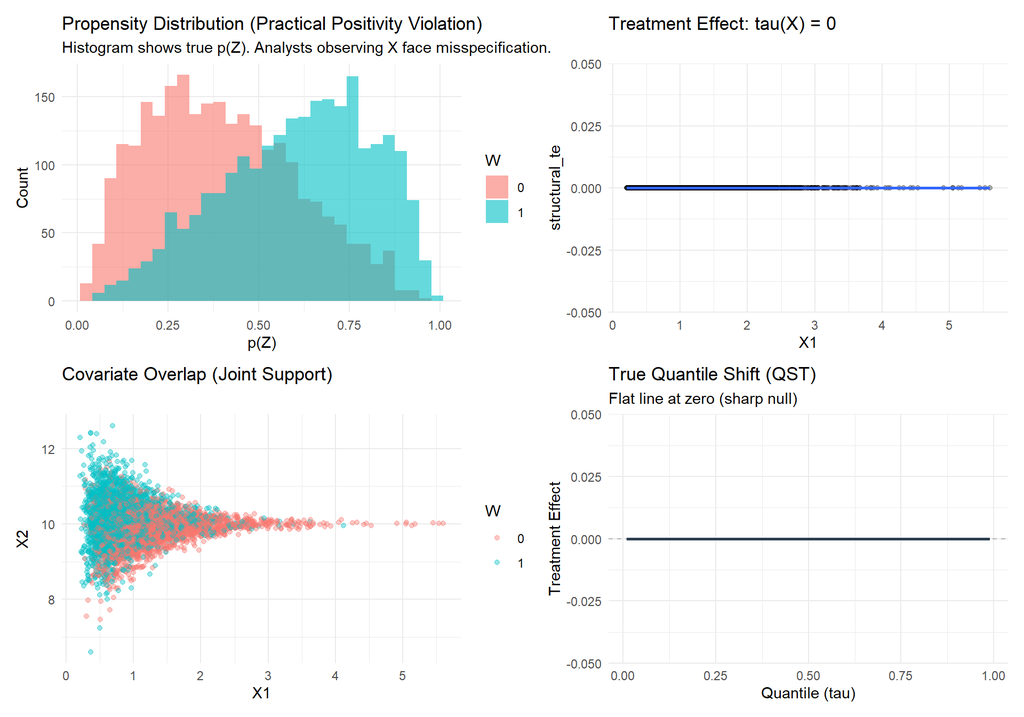

## 7. Empirical Validation

Oracle should be zero. IPW is expected to be noisy or biased under misspecification.

Empirical validation (n=1000, seeds=1:20)

| estimator_id | mean_bias | rmse |
| --- | --- | --- |
| ipw_att | -6.871 | 7.052 |
| oracle_att | 0.000 | 0.000 |

## 9. Implementation Reference

- Generator: `R/dgp-synth-placebo-kangschafer.R`
- Registry: `cs_dgp_registry()` entry for `synth_placebo_kangschafer`
- Oracle truth: `cs_get_oracle_qst("synth_placebo_kangschafer", version = "1.4.0")`

## 10. Validation Checklist

- Sharp null (Y1 == Y0) enforced
- Nonlinear transforms of latent Z documented
- Propensity histogram shows skew/edge mass
- Oracle returns zero effect
- IPW fragility explained

## 11. Changelog

- v1.4.0 (2026-01-06): Revised dossier with Kang-Schafer citation and misspecification narrative.

## Appendix: Implementation

```
Source code for: dgp_synth_placebo_kangschafer_v140

function(n, seed = NULL, include_truth = TRUE, oracle_only = FALSE) {
  if (!is.null(seed)) {
    cs_set_rng(seed)
  }

  Z1 <- stats::rnorm(n, mean = 0, sd = 1)
  Z2 <- stats::rnorm(n, mean = 0, sd = 1)
  Z3 <- stats::rnorm(n, mean = 0, sd = 1)
  Z4 <- stats::rnorm(n, mean = 0, sd = 1)

  X1 <- exp(Z1 / 2)
  X2 <- Z2 / (1 + exp(Z1)) + 10
  X3 <- (Z1 * Z3 / 25 + 0.6)^3
  X4 <- (Z2 + Z4 + 20)^2

  lin_ps <- -Z1 + 0.5 * Z2 - 0.25 * Z3 - 0.1 * Z4
  p      <- stats::plogis(lin_ps)
  w      <- stats::rbinom(n, size = 1L, prob = p)

  mu0 <- 210 + 27.4 * Z1 + 13.7 * Z2 + 13.7 * Z3 + 13.7 * Z4
  eps <- stats::rnorm(n, mean = 0, sd = 1)

  y0 <- mu0 + eps
  y1 <- y0
  if (isTRUE(oracle_only)) {
    return(list(df = tibble::tibble(w = w, y0 = y0, y1 = y1)))
  }
  y  <- ifelse(w == 1L, y1, y0)

  tau <- rep(0, n)

  true_att <- cs_true_att(structural_te = tau, w = w)
  true_qst <- if (isTRUE(include_truth)) cs_get_oracle_qst("synth_placebo_kangschafer", version = "1.4.0") else NULL

  out <- list(
    df = tibble::tibble(
      y  = y,
      w  = w,
```

[output cut: 10 more lines]

```
    true_qst = true_qst,
    meta = list(
      dgp_id        = "synth_placebo_kangschafer",
      version       = "1.4.0",
      type          = "synthetic",
      params        = list(n = n, seed = seed),
      structural_te = tau
    )
  )

  cs_check_dgp_synthetic(out)
  out
}
<bytecode: 0x000001d54e196d60>
<environment: namespace:CausalStress>
```